# MSDS6306 Case Study 1

Ivan Charkin, Laura Niederlander, Shon Mohsin

June 27, 2018

## Introduction

This case study analyzes two files. One file contains information on breweries and another on beers. The goal is to merge the two files and do analysis of the data. Both output and R code are shown in the discussion below.

### 1. How many breweries are present in each state?

```r
#Load data from Github
br <- read.csv("https://raw.githubusercontent.com/icharkin/ICharkin_MSDS6306_HW/master/CaseStudy1/Breweries.csv", header=TRUE)
beers <- read.csv ("https://raw.githubusercontent.com/icharkin/ICharkin_MSDS6306_HW/master/CaseStudy1/Beers.csv", header=TRUE)

brnum<-summary (br$State)
brnum
```

```
##  AK  AL  AR  AZ  CA  CO  CT  DC  DE  FL  GA  HI  IA  ID  IL  IN  KS  KY
##   7   3   2  11  39  47   8   1   2  15   7   4   5   5  18  22   3   4
##  LA  MA  MD  ME  MI  MN  MO  MS  MT  NC  ND  NE  NH  NJ  NM  NV  NY  OH
##   5  23   7   9  32  12   9   2   9  19   1   5   3   3   4   2  16  15
##  OK  OR  PA  RI  SC  SD  TN  TX  UT  VA  VT  WA  WI  WV  WY
##   6  29  25   5   4   1   3  28   4  16  10  23  20   1   4
```

This must be an outdated data set since there are likely much more breweries at the present time.

For convenience with data analysis we renamed several columns in the data sets.

```r
#Align the names between datasets
#Only columns common to the two datasets is Brewery ID
colnames(beers)[1] <- "Beer_name"
colnames(br)[1] <- "Brewery_id"
colnames(br)[2] <- "Brewery_name"

merged <- merge(br, beers)
head (merged)
```

```
##   Brewery_id       Brewery_name        City State     Beer_name Beer_ID
## 1          1 NorthGate Brewing  Minneapolis    MN       Pumpion    2689
## 2          1 NorthGate Brewing  Minneapolis    MN    Stronghold    2688
## 3          1 NorthGate Brewing  Minneapolis    MN   Parapet ESB    2687
## 4          1 NorthGate Brewing  Minneapolis    MN  Get Together    2692
## 5          1 NorthGate Brewing  Minneapolis    MN Maggie's Leap    2691
## 6          1 NorthGate Brewing  Minneapolis    MN    Wall's End    2690
##     ABV IBU                               Style Ounces
## 1 0.060  38                         Pumpkin Ale     16
## 2 0.060  25                     American Porter     16
## 3 0.056  47 Extra Special / Strong Bitter (ESB)     16
## 4 0.045  50                        American IPA     16
## 5 0.049  26                  Milk / Sweet Stout     16
## 6 0.048  19                   English Brown Ale     16
```

The data are successfully merged.

### 3. Report the number of NA’s in each column.

```r
colSums(is.na(merged))
```

```
##   Brewery_id Brewery_name         City        State    Beer_name
##            0            0            0            0            0
##      Beer_ID          ABV          IBU        Style       Ounces
##            0           62         1005            0            0
```

All NA’s are in ABV and IBU columns. We have to be careful with the further analysis of these variables as it is obvious that the data set is incomplete.

### 4. Compute the median alcohol content and international bitterness unit for each state. Plot a bar chart to compare.

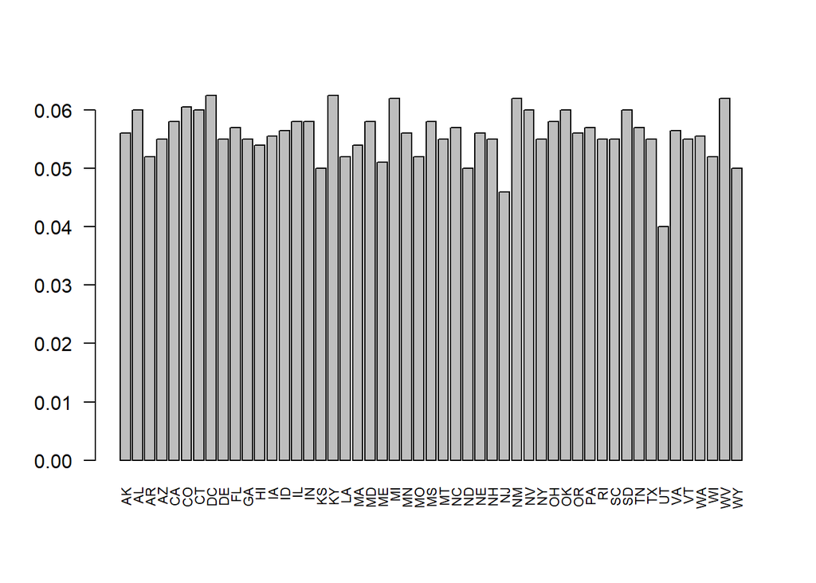

```r
ABV<-tapply (merged$ABV, merged$State, median, na.rm = TRUE)
barplot(ABV, las=2, cex.names=0.7)
```

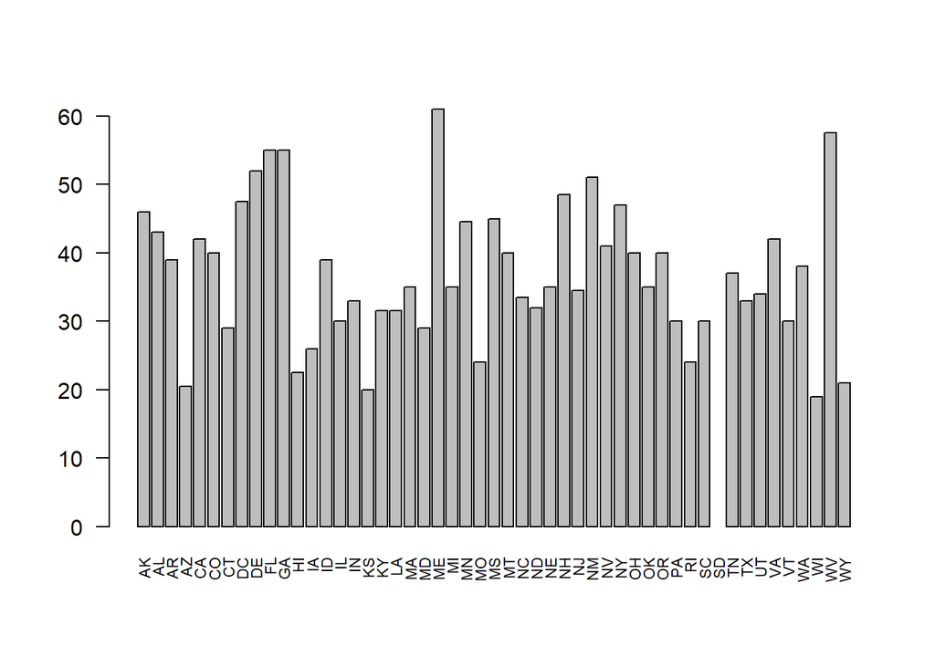

```r
IBU<-tapply (merged$IBU, merged$State, median, na.rm = TRUE)
barplot(IBU, las=2, cex.names=0.7)
```

There is much more variation in the Bitterness between states than in alcohol content.

### 5. Which state has the maximum alcoholic (ABV) beer? Which state has the most bitter (IBU) beer?

```r
as.character (merged$State [which (merged$ABV==max (merged$ABV, na.rm=TRUE) )]  )
```

```
## [1] " CO"
```

```r
as.character (merged$State [which (merged$IBU==max (merged$IBU, na.rm=TRUE) )]  )
```

```
## [1] " OR"
```

Colorado has the beer with the maximum alcohol content. OR has the most bitter beer.

### 6. Summary statistics for the ABV variable.

```r
summary(merged$ABV)
```

```
##    Min. 1st Qu.  Median    Mean 3rd Qu.    Max.    NA's
## 0.00100 0.05000 0.05600 0.05977 0.06700 0.12800      62
```

### 7. Is there an apparent relationship between the bitterness of the beer and its alcoholic content? Draw a scatter plot.

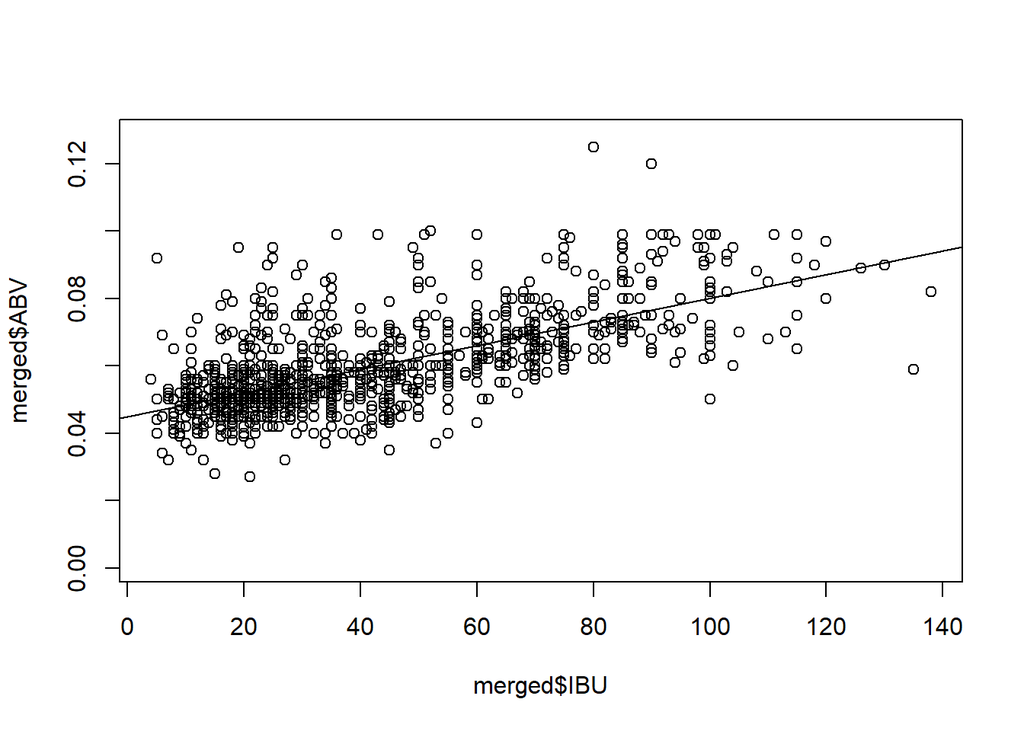

```r
plot(merged$IBU, merged$ABV)
abline(lm(merged$ABV ~ merged$IBU))
```

```r
summary (lm(merged$ABV ~ merged$IBU))
```

```
##
## Call:
## lm(formula = merged$ABV ~ merged$IBU)
##
## Residuals:
##       Min        1Q    Median        3Q       Max
## -0.033288 -0.005946 -0.001595  0.004022  0.052006
##
## Coefficients:
##              Estimate Std. Error t value Pr(>|t|)
## (Intercept) 4.493e-02  5.177e-04   86.79   <2e-16 ***
## merged$IBU  3.508e-04  1.036e-05   33.86   <2e-16 ***
## ---
## Signif. codes:  0 '***' 0.001 '**' 0.01 '*' 0.05 '.' 0.1 ' ' 1
##
## Residual standard error: 0.01007 on 1403 degrees of freedom
##   (1005 observations deleted due to missingness)
## Multiple R-squared:  0.4497, Adjusted R-squared:  0.4493
## F-statistic:  1147 on 1 and 1403 DF,  p-value: < 2.2e-16
```